# Visualising phylogenies in R

## Natalie Cooper (natalie.cooper@nhm.ac.uk)

## 1. Introduction

This is a quick practical to introduce you to some of the fun ways you can visualise phylogenetic trees in R. The code and examples are based on Liam Revell’s book chapter [here](http://faculty.umb.edu/liam.revell/pdfs/Revell_2014.MPCM-chapter.pdf). I am assuming that people have little or no experience with R so more experienced users may want to skim quickly through the first few sections.

Throughout, R code will be in shaded boxes:

```r
library(ape)
```

R output will be preceded by ## and important comments will be in quote blocks:

> Note that many things in R can be done in multiple ways. You should choose the methods you feel most comfortable with, and do not panic if someone is doing the same analyses as you in a different way!

## 2. Preparations

### Downloading R (and RStudio)

If you don’t already have it you’ll need to download R from [CRAN](https://cran.r-project.org/). I also recommend using [RStudio](https://www.rstudio.com/products/rstudio/download/) but you don’t need this.

### Downloading the data and phylogeny

First you need to download all the files for this practical into a folder somewhere on your computer (I usually put mine on the Desktop). You’ll need to know what the **path** of the folder is. For example on my Windows machine, the path is:

```r
C:/Users/Natalie/Desktop/RAnalyses
```

The path is really easy to find in a Windows machine, just click on the address bar of the folder and the whole path will appear.

On my Mac the path is:

```r
~/Desktop/RAnalyses
```

It’s a bit trickier to find the path on a Mac, so ask if you need help. Note that the tilde ~ is a shorthand for /Users/Natalie.

### Using a script

Next open R (or RStudio) and then open a text editor. R has an inbuilt editor that works pretty well, but NotePad and TextEdit are fine too. However, in the future I **highly** recommend using something that will highlight code for you. My personal favorite is Sublime Text 2, because you can also use it for any other kind of text editing like LaTeX, html etc. RStudio’s editor is also very nice.

You should type (or copy and paste) your code into the text editor, edit it until you think it’ll work, and then paste it into R’s console window. Saving the script file lets you keep a record of the code you used, which can be a great timesaver if you want to use it again, especially as you know this code will work!

> You can cut and paste code from this handout into your script. You don’t need to retype everything!

If you want to add comments to the file (i.e., notes to remind yourself what the code is doing), put a hash/pound sign (#) in front of the comment.

```r
# Comments are ignored by R but remind you what the code is doing.
# You need a # at the start of each line of a comment.
# Always make plenty of notes to help you remember what you did and why
```

### Setting the working directory

We can the set the working directory to the folder containing your data using `setwd`:

```r
setwd("~/Desktop/RAnalyses")
```

Setting the working directory tells R which folder to look for data in (and which folder you’d like it to write results to). It saves a bit of typing when reading files into R. Now I can read in a file called `mydata.csv` as follows:

```r
mydata <- read.csv("mydata.csv")
```

rather than having to specify the folder too:

```r
mydata <- read.csv("~/Desktop/RAnalyses/mydata.csv")
```

If you’d rather specify the path and not set the working directory that’s fine.

### Installing and loading extra packages in R

To plot phylogenies (or use any specialized analysis) in R, you need to download one or more additional packages from the basic R installation. For this practical you will need to install the following packages:

- `ape`
- `phytools`

To install the package `ape`:

```r
install.packages("ape")
```

Pick the closest mirror to you if asked. Now install `phytools`.

You’ve installed the packages but they don’t automatically get loaded into your R session. Instead you need to tell R to load them **every time** you start a new R session and want to use functions from these packages. To load the package `ape` into your current R session:

```r
library(ape)
```

You can think of `install.packages` like installing an app from the App Store on your smart phone - you only do this once - and `library` as being like pushing the app button on your phone - you do this every time you want to use the app.

Don’t forget to load `phytools` too!

```r
library(phytools)
```

## 3. Loading your phylogeny and data into R

### Reading in a phylogeny from a file

To load a tree you need either the function `read.tree` or `read.nexus`. `read.tree` can deal with a number of different types of data (including DNA) whereas `read.nexus` reads NEXUS files. `elopomorph.tre` is not in NEXUS format so we use `read.tree`.

```r
fishtree <- read.tree("elopomorph.tre")
```

### Reading in a phylogeny that is already built into R

The bird and anole phylogenies are already built into R so we don’t need to read them in using `read.tree`. Instead we just use:

```r
data(bird.orders)
data(anoletree)
```

### Reading and viewing your data in R

Later we will use some Greater Antillean *Anolis* lizard data to add data to a phylogeny. Before we can add data to our tree, we need to load the data we are going to use. R can read files in lots of formats, including comma-delimited and tab-delimited files. Excel (and many other applications) can output files in this format (it’s an option in the `Save As` dialog box under the `File` menu). To save time I have given you a comma-delimited text file called `anole.data.csv` which we are going to use. Load these data as follows. I am assuming you have set your working directory, if not don’t forget the path.

```r
anoledata <- read.csv("anole.data.csv", header = TRUE)
```

You can use `read.delim` for tab delimited files or `read.csv` for comma delimited files. `header = TRUE`, indicates that the first line of the data contains column headings.

This is a good point to note that unless you R you want to do something, it won’t do it automatically. So here if you successfully entered the data, R won’t give you any indication that it worked. Instead you need to specifically ask R to look at the data.

We can look at the data by typing:

```r
str(anoledata)
```

```
## 'data.frame':    100 obs. of  23 variables:
##  $ species               : Factor w/ 100 levels "ahli","alayoni",..: 1 2 3 4 5 6 7 8 9 10 ...
##  $ AVG.SVL               : num  4.04 3.82 3.53 4.04 4.38 ...
##  $ AVG.hl                : num  2.88 2.7 2.38 2.9 3.36 ...
##  $ AVG.hw                : num  2.36 1.99 1.56 2.37 2.69 ...
##  $ AVG.hh                : num  2.13 1.75 1.39 2.05 2.32 ...
##  $ AVG.ljl               : num  2.85 2.71 2.32 2.9 3.38 ...
##  $ AVG.outlever          : num  2.75 2.62 2.26 2.83 3.29 ...
##  $ AVG.jugal.to.symphysis: num  2.54 2.37 2.08 2.6 3.07 ...
##  $ AVG.femur             : num  2.74 2.07 2.17 2.48 2.8 ...
##  $ AVG.tibia             : num  2.69 2.02 2.09 2.34 2.69 ...
##  $ AVG.met               : num  2.25 1.54 1.55 1.87 2.18 ...
##  $ AVG.ltoe.IV           : num  2.55 1.88 1.73 2.26 2.53 ...
##  $ AVG.toe.IV.lam.width  : num  0.1795 0.0488 -0.5361 0.4904 0.8441 ...
##  $ AVG.humerus           : num  2.46 1.95 1.63 2.3 2.62 ...
##  $ AVG.radius            : num  2.27 1.69 1.4 2.09 2.34 ...
##  $ AVG.lfing.IV          : num  1.94 1.4 1.04 1.7 1.98 ...
##  $ AVG.fing.IV.lam.width : num  0.0754 -0.0739 -0.755 0.3155 0.6584 ...
##  $ AVG.pelv.ht           : num  1.99 1.51 1.19 1.87 2.1 ...
##  $ AVG.pelv.wd           : num  1.71 1.419 0.946 1.752 2.014 ...
##  $ Foot.Lam.num          : num  3.28 3.43 3.2 3.58 3.72 ...
##  $ Hand.Lam.num          : num  2.87 3.08 2.73 3.16 3.24 ...
##  $ Avg.lnSVL2            : num  3.94 3.74 3.48 3.93 4.36 ...
##  $ Avg.ln.t1             : num  4.41 4 4.37 4.44 5.04 ...
```

**Always** look at your data before beginning any analysis to check it read in correctly.

`str` shows the structure of the data frame (this can be a really useful command when you have a big data file). It also tells you what kind of variables R thinks you have (characters, integers, numeric, factors etc.). Some R functions need the data to be certain kinds of variables so it’s useful to check this.

```r
head(anoledata)
```

```
##    species  AVG.SVL   AVG.hl   AVG.hw   AVG.hh  AVG.ljl AVG.outlever
## 1     ahli 4.039125 2.882657 2.356126 2.131599 2.854745     2.754934
## 2  alayoni 3.815705 2.702116 1.990610 1.751588 2.708966     2.617852
## 3  alfaroi 3.526655 2.378156 1.556037 1.390037 2.323857     2.263844
## 4 aliniger 4.036557 2.898836 2.366592 2.046660 2.903946     2.828555
## 5 allisoni 4.375390 3.358957 2.690339 2.317309 3.381306     3.288402
## 6  allogus 4.040138 2.861027 2.351275 2.142107 2.848331     2.750404
##   AVG.jugal.to.symphysis AVG.femur AVG.tibia  AVG.met AVG.ltoe.IV
## 1               2.538052  2.741378  2.686032 2.254620    2.553344
## 2               2.371995  2.065121  2.016402 1.535253    1.875258
## 3               2.077565  2.172476  2.094946 1.547563    1.732540
## 4               2.596821  2.475445  2.344015 1.867176    2.256541
## 5               3.071149  2.795145  2.687734 2.178155    2.533697
## 6               2.539320  2.739175  2.684476 2.217314    2.494900
##   AVG.toe.IV.lam.width AVG.humerus AVG.radius AVG.lfing.IV
```

[output cut: 20 more lines]

This gives you the first few rows of data along with the column headings.

```r
names(anoledata)
```

```
##  [1] "species"                "AVG.SVL"
##  [3] "AVG.hl"                 "AVG.hw"
##  [5] "AVG.hh"                 "AVG.ljl"
##  [7] "AVG.outlever"           "AVG.jugal.to.symphysis"
##  [9] "AVG.femur"              "AVG.tibia"
## [11] "AVG.met"                "AVG.ltoe.IV"
## [13] "AVG.toe.IV.lam.width"   "AVG.humerus"
## [15] "AVG.radius"             "AVG.lfing.IV"
## [17] "AVG.fing.IV.lam.width"  "AVG.pelv.ht"
## [19] "AVG.pelv.wd"            "Foot.Lam.num"
## [21] "Hand.Lam.num"           "Avg.lnSVL2"
## [23] "Avg.ln.t1"
```

This gives you the names of the columns.

```r
anoledata
```

This will print out all of the data!

## 4. Basic tree viewing in R

Now let’s visualise some phylogenies! We’ll use the Elopomorpha (eels and similar fishes) tree to start as it is simple.

```r
fishtree <- read.tree("elopomorph.tre")
```

Let’s examine the tree by typing:

```r
fishtree
```

```
##
## Phylogenetic tree with 62 tips and 61 internal nodes.
##
## Tip labels:
##  Moringua_edwardsi, Kaupichthys_nuchalis, Gorgasia_taiwanensis, Heteroconger_hassi, Venefica_proboscidea, Anguilla_rostrata, ...
##
## Rooted; includes branch lengths.
```

```r
str(fishtree)
```

```
## List of 4
##  $ edge       : int [1:122, 1:2] 63 64 64 65 66 67 68 68 69 70 ...
##  $ Nnode      : int 61
##  $ tip.label  : chr [1:62] "Moringua_edwardsi" "Kaupichthys_nuchalis" "Gorgasia_taiwanensis" "Heteroconger_hassi" ...
##  $ edge.length: num [1:122] 0.0105 0.0672 0.00537 0.00789 0.00157 ...
##  - attr(*, "class")= chr "phylo"
##  - attr(*, "order")= chr "cladewise"
```

`fishtree` is a fully resolved tree with branch lengths. There are 62 species and 61 internal nodes. We can plot the tree by using the `plot.phylo` function of `ape`. Note that we can just use the function `plot` to do this as R knows if we ask it to plot a phylogeny to use `plot.phylo` instead!

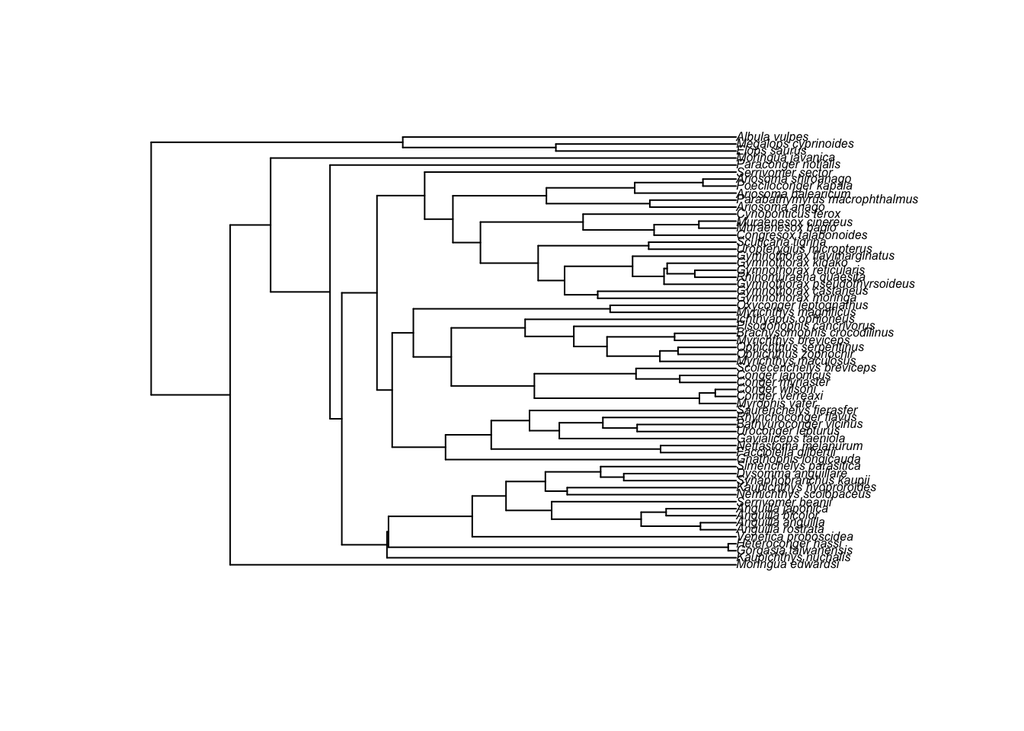

```r
plot(fishtree, cex = 0.5)
```

`cex = 0.5` reduces the size of the tip labels so we can read them. We can also zoom into different sections of the tree that you’re interested in:

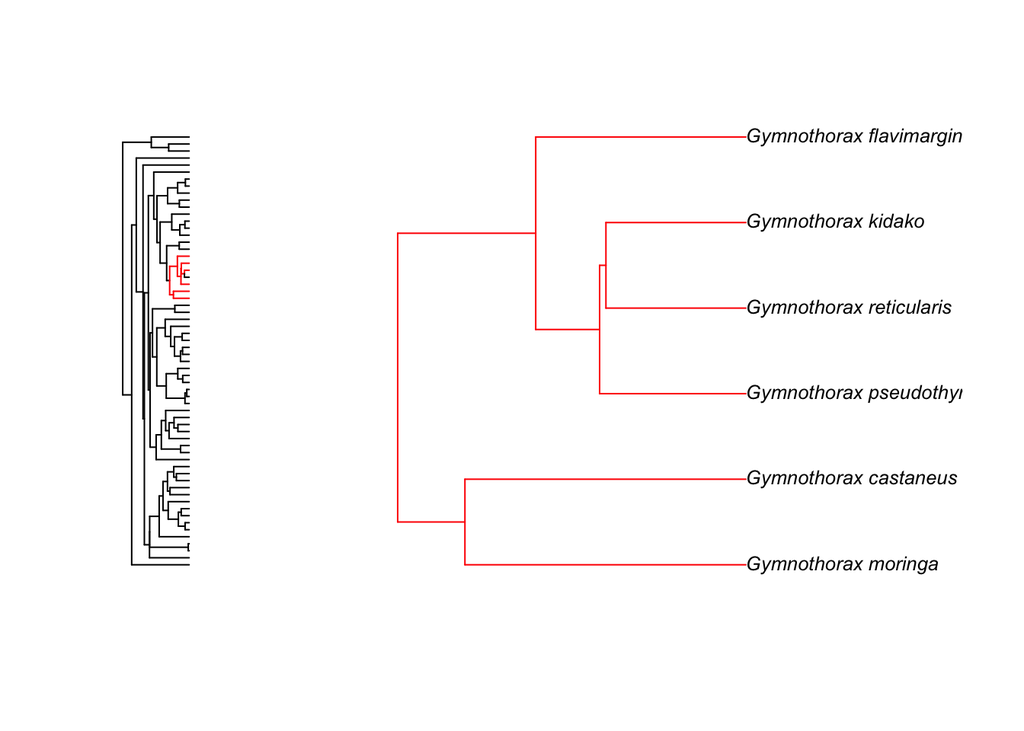

```r
zoom(fishtree, grep("Gymnothorax", fishtree$tip.label), subtree = FALSE, cex = 0.8)
```

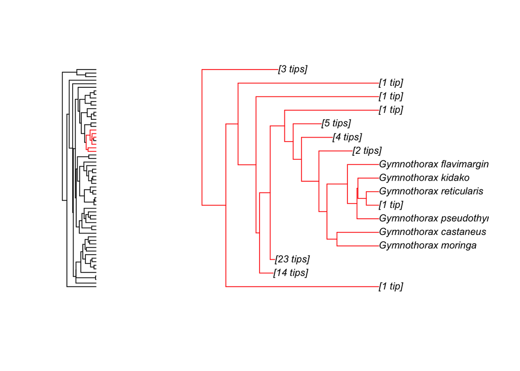

```r
zoom(fishtree, grep("Gymnothorax", fishtree$tip.label), subtree = TRUE, cex = 0.8)
```

Note that `zoom` automatically sets the plotting window to display two plots at once. To reset this to one plot only use:

```r
par(mfrow = c(1, 1))
```

To get further options for the plotting of phylogenies:

```r
?plot.phylo
```

Note that although you can use `plot` to plot the phylogeny, you need to specify `plot.phylo` to find out the options for plotting trees. You can change the style of the tree (`type`), the color of the branches and tips (`edge.color`, `tip.color`), and the size of the tip labels (`cex`). Here’s an fun/hideous example!

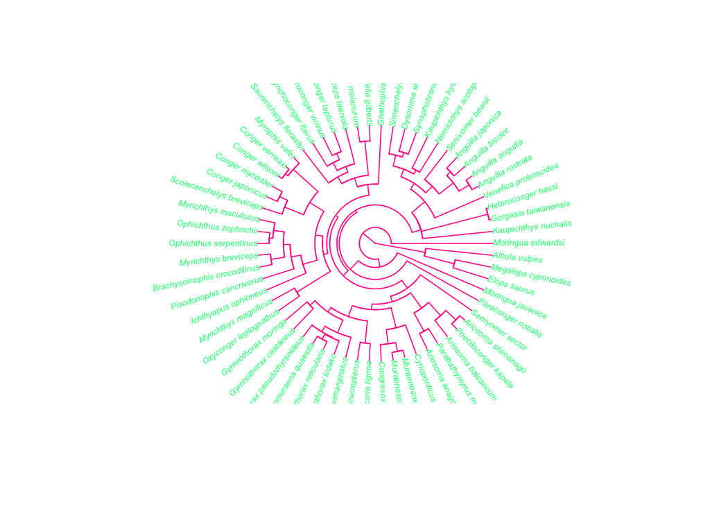

```r
plot(fishtree, type = "fan", edge.color = "deeppink", tip.color = "springgreen",
     cex = 0.5)
```

Or try

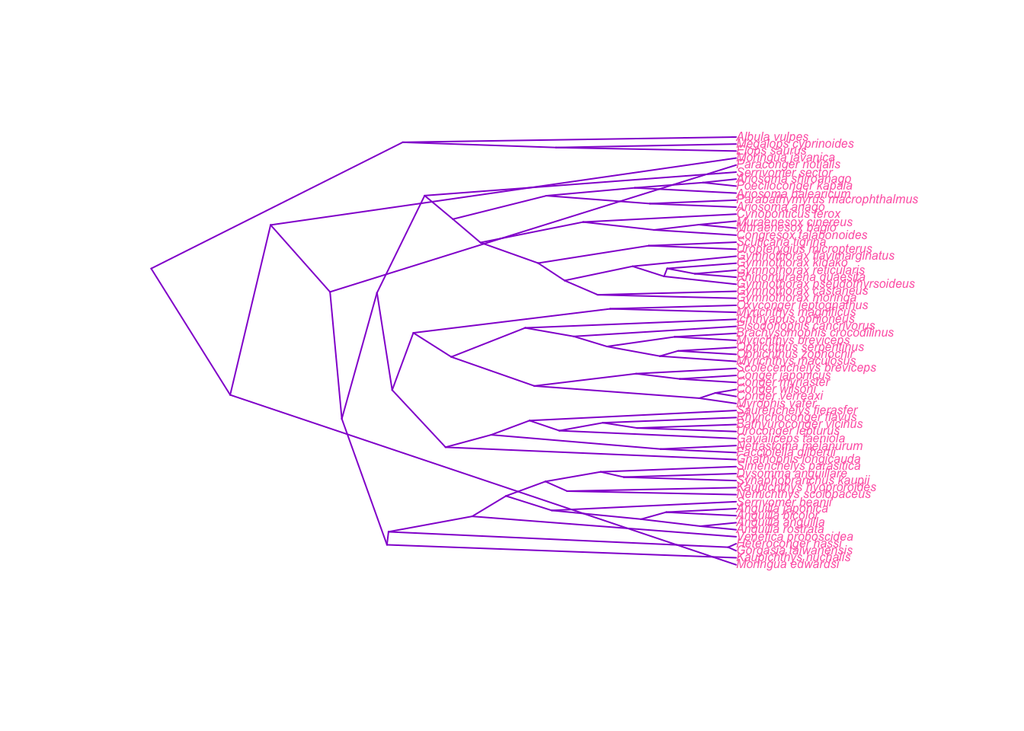

```r
plot(fishtree, type = "c", edge.color = "darkviolet", tip.color = "hotpink",
     cex = 0.5)
```

## 5. Adding trait data to trees in R

### A. Ancestral state reconstructions on discrete data

We will use the bird data Remember we already loaded the phylogeny and data as follows:

```r
data(bird.orders)
```

First we will invent some data for each bird order that we can reconstruct along the tree. This creates three variables, 0, 1 and 2.

```r
mydata <- factor(c(rep(0, 5), rep(1, 13), rep(2, 5)))
mydata
```

```
##  [1] 0 0 0 0 0 1 1 1 1 1 1 1 1 1 1 1 1 1 2 2 2 2 2
## Levels: 0 1 2
```

We can then use the `ape` function `ace` to reconstruct ancestral characters along the nodes of the tree. `type = d` means the character to be reconstructed is discrete.

```r
ancestors <- ace(mydata, bird.orders, type = "d")
```

Now we can plot this on a phylogeny. First decide which colours we’d like. To look at a list of colours in R type in `colors()`.

```r
colours <- c("cornflowerblue", "cyan4", "goldenrod")
```

Now plot the tree and add labels to the tips and the nodes using the results in `ancestors`. We use `label.offset = 1` to move the labels to the right a bit so the pie charts will fit…

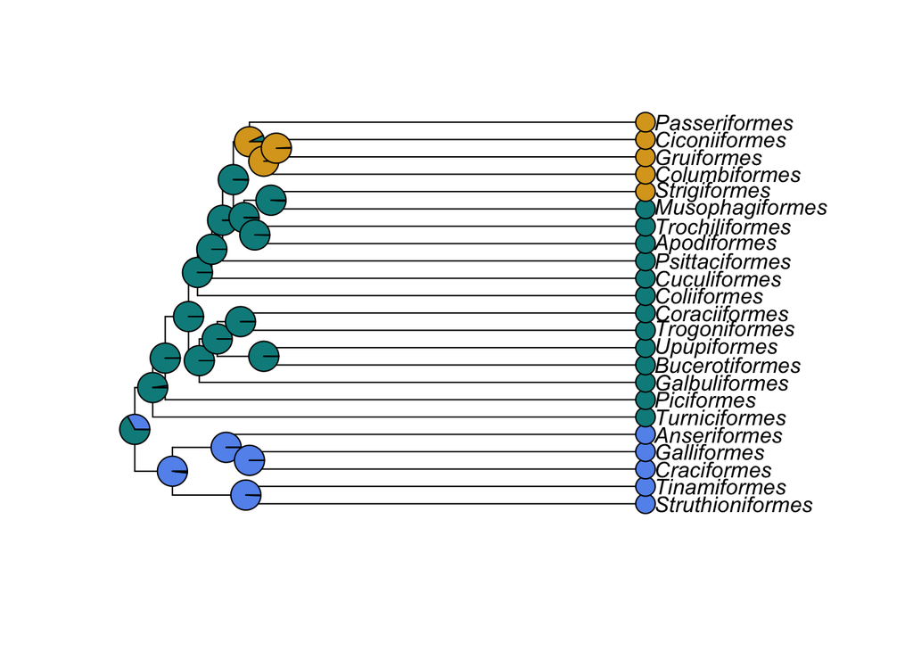

```r
plot(bird.orders, label.offset = 1)
tiplabels(pch = 21, bg = colours[as.numeric(mydata)], cex = 2, adj = 1)
nodelabels(pie = ancestors$lik.anc, piecol = colours)
```

`pch = 21` sets the tip labels to be unfilled circles, `bg` defines the colours of the circles using the list of colours we provided, and ordering them based on what the species value was for mydata (i.e. 0, 1 or 2). `cex = 2` doubles the point size, and `adj = 1` moves the tip labels sideways so they don’t obscure the ends of the branches. `pie` makes pie charts coloured using the ancestral state reconstructions in `ancestors`, and `piecol` tells it to use the colours we have defined.

### B. Ancestral state reconstructions on continuous data

We are going to use the *Anolis* data to create a phylogeny with different colours for different observed and reconstructed body sizes (snout-to-vent length, SVL). Remember we already loaded the phylogeny and data as follows:

```r
data(anoletree)
anoledata <- read.csv("anole.data.csv", header = TRUE, row.names = 1)
```

Note the names in `anoledata` are the species names without the Genus. In the phylogeny the species names are `Anolis_species`. So to get the two to match we need to add `Anolis_` to each name.

```r
rownames(anoledata) <- paste("Anolis", rownames(anoledata), sep = "_")
```

`paste` just sticks together `Anolis` with the names in `anoles` already with an underscore (`_`) separating them (`sep = "_"`)

We then need to make sure the order of the species in the data matches that of the phylogeny.

```r
anoledata <- anoledata[anoletree$tip.label, ]
```

Next we make a matrix containing only the SVL values for each *Anolis* species:

```r
SVL <- as.matrix(anoledata)[,"AVG.SVL"]
```

This code selects only the variable `AVG.SVL` from `anoledata` (square brackets subset in R in the form [rows, columns]), and then uses `as.matrix` to make this into a matrix.

Take a look at `SVL`

```r
head(SVL)
```

```
##        Anolis_ahli     Anolis_allogus Anolis_rubribarbus
##           4.039125           4.040138           4.078469
##       Anolis_imias      Anolis_sagrei     Anolis_bremeri
##           4.099687           4.067162           4.113371
```

We then use the function `contMap`. `contMap` creates a tree with a mapped continuous character, i.e. where the value of the character is known at the tips, and estimated along the tree. The estimating of the character along the tree uses a Maximum Likelihood estimation procedure. Here we will tell `contMap` not to automatically plot the tree (using `plot = FALSE`) so we can make some modifications.

```r
SVLplot <- contMap(anoletree, SVL, plot = FALSE)
```

```
## legend scale cannot be longer than total tree length; resetting
```

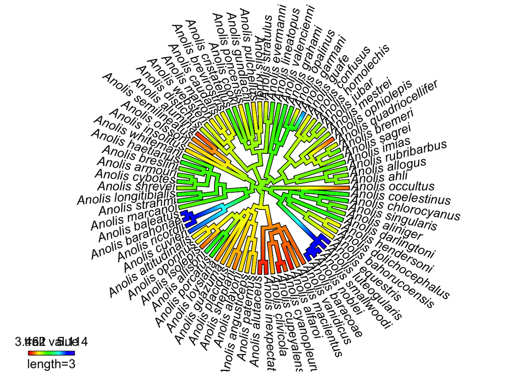

```r
plot(SVLplot, type = "fan", legend = 10)
```

## 6. Phylomorphospace plots in R

We are going to use the *Anolis* data to create a phylomorphospace plot. These plots show where species fall within a morphospace (usually based on principal components analyses of morphological variables), and then reconstructs values for the nodes of the phylogeny so the whole phylogeny can be projected into the morphospace.

We already loaded the phylogeny and data as follows:

```r
data(anoletree)
anoledata <- read.csv("anole.data.csv", header = TRUE, row.names = 1)
```

As we saw above, the names of `anoles` are the species names without the Genus. In the phylogeny the species names are `Anolis_species`. So to get the two to match we need to add `Anolis_` to each name.

```r
rownames(anoledata) <- paste("Anolis", rownames(anoledata), sep = "_")
```

`paste` just sticks together `Anolis` with the names in `anoles` already with an underscore (`_`) separating them (`sep = "_"`)

Next we again need to make sure the order of the species in the data matches that of the phylogeny.

```r
anoledata <- anoledata[anoletree$tip.label, ]
```

We can now run a phylogenetic principal components analysis on our morphological trait data and extract the PC scores for each PC axis using `$S`.

```r
PC <- phyl.pca(anoletree, anoledata)$S
```

To plot the morphospace with colours, we need to define them. Here we choose six colours, and matched them with the ecomorph types listed [here](https://en.wikipedia.org/wiki/Anolis_ecomorphs). These were built into `anoletree`.

```r
colors <- setNames(c("cornflowerblue", "goldenrod", "chartreuse", "hotpink",
                     "orangered", "darkviolet"),
                     sort(unique(getStates(anoletree, "tips"))))
```

Finally we can make the plot, and colour by ecomorph. `label = "off"` suppresses the printing of tip labels which keeps things a bit tidier.

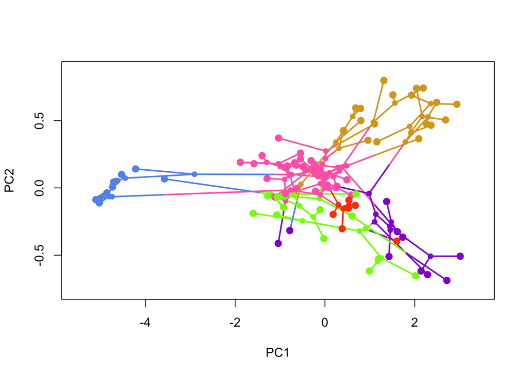

```r
phylomorphospace(anoletree, PC[,1:2], label = "off", node.by.map = TRUE, colors = colors)
```

## 7. Phylogenies and maps!

We can also plot phylogenies attached to maps showing where species come from. We will use the bird orders tree again as it’s small.

```r
data(bird.orders)
```

We don’t know where the birds come from, so we will simulate some latitude and longitude data as follows. This uses a function that simulates traits along the phylogeny, so close relatives should end up with more similar latitude and longitude values. I’ve used high rates of evolution (`sig2`) to force the points to be spread out. Of course these values will be nonsensical for birds!

```r
lat <- fastBM(bird.orders, sig2 = 100, bounds = c(-90, 90))
long <- fastBM(bird.orders, sig2 = 150, bounds = c(-180, 180))
```

Then we use the function `phylo.to.map` to match the locations with the world map. This produces some output in the form `objective 98` etc. (I have suppressed it here).

```r
phylomap <- phylo.to.map(bird.orders, cbind(lat,long), plot = FALSE)
```

We can either put the phylogeny next to the map and draw lines to the places they come from using `type = "phylogram"`…

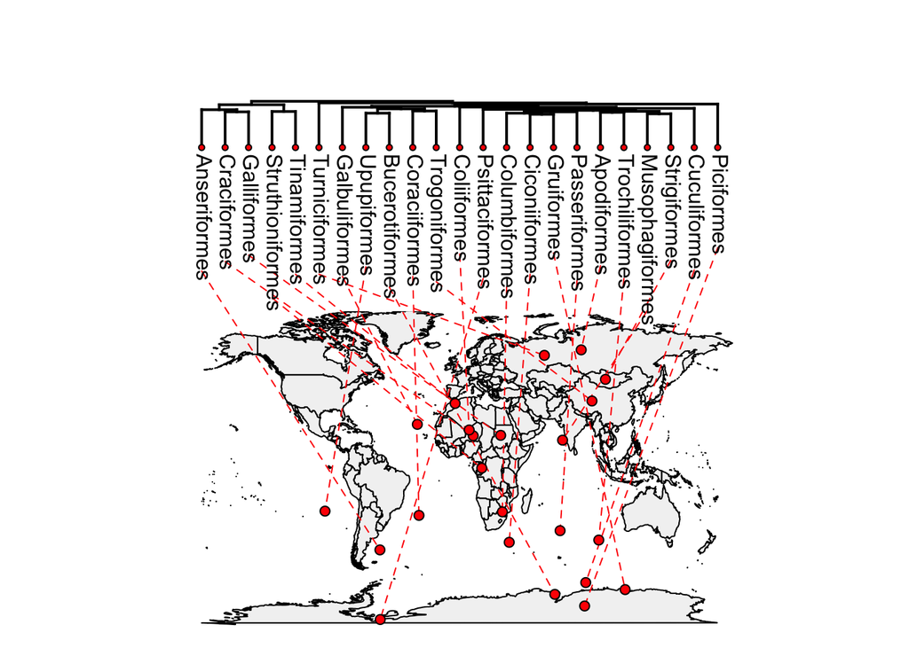

```r
plot(phylomap,type = "phylogram", asp = 1.3, mar = c(0.1, 0.5, 3.1, 0.1))
```

…or plot the phylogeny directly onto the map using `type = "direct"`

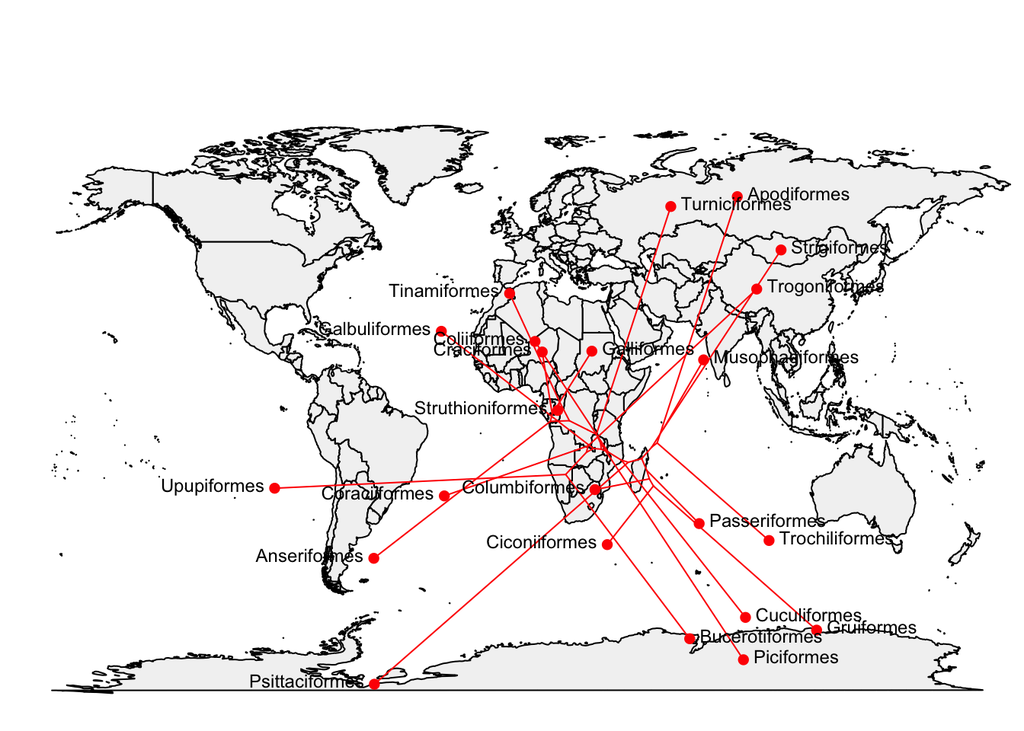

```r
plot(phylomap,type = "direct", asp = 1.3, mar = c(0.1, 0.5, 3.1, 0.1))
```